# SAE - Sustentacões Orais e Pedidos de Destaque

## Sustentações Orais

O arquivo de sustentações orais possui [816](https://shiny.rstudio.com/reference/shiny/latest/fluidPage.html) entradas originalmente. Aplicando os devidos filtros para manter apenas processos do período de pesquisa, restam [619](https://shiny.rstudio.com/reference/shiny/latest/fluidPage.html) sustentações orais em [348](https://getbootstrap.com/) processos. Especificamente para as sustentações orais é interessante saber de quais unidades da federação os advogados responsáveis possuem registro da OAB. A imensa maioria das entradas não contém informação de OAB ([504](https://rstudio.github.io/bslib/reference/bs_theme.html)) e a disposição por UF das entradas restantes será apresentada a seguir. Os estados DF, SP, PR e RJ concentram mais de [75%](https://rstudio.github.io/bslib/reference/bs_theme.html) das [115](https://rstudio.github.io/bslib/reference/bs_theme.html) entradas com registro de OAB. Outras análises interessantes envolvem a classe processual e a quantidade de entradas por orgão julgador, a saber: [Primeira Turma (1T), Segunda Turma (2T) e Tribunal Pleno (TP)](https://rstudio.github.io/bslib/reference/bs_theme.html). Importante ressaltar que todas as entradas de sustentação oral ocorrem no período de 20/03/2020 até 31/12/2020. Na lista apresentada, a variável parte_1 é a parte representada, enquanto a parte_2 é o nome do representante. Os quadros e gráficos seguem:

## Gráficos e Quadros - Sustentações Orais

### UF - OAB

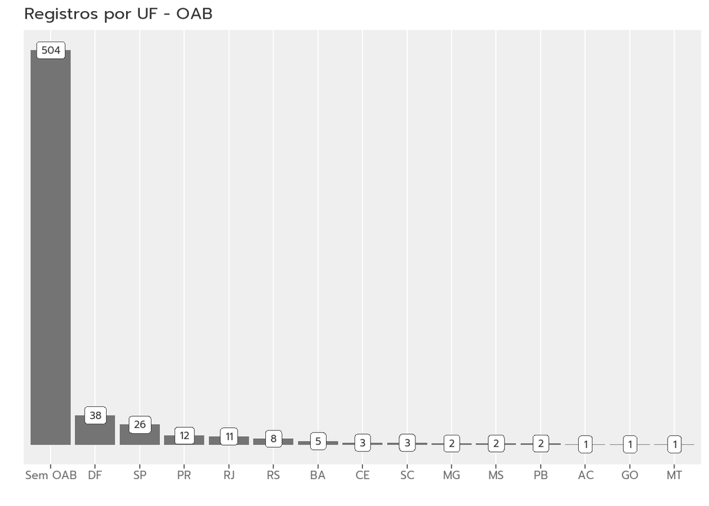

### Classes

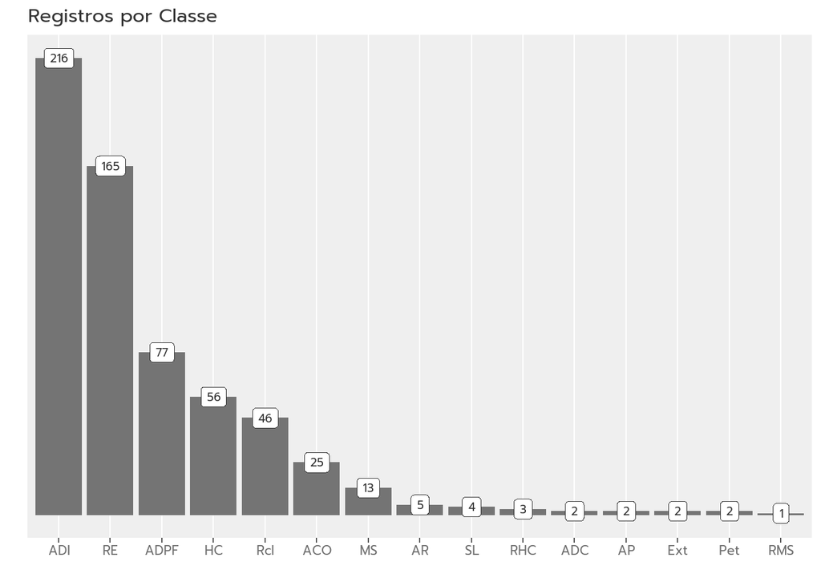

### Classes - Registros Únicos

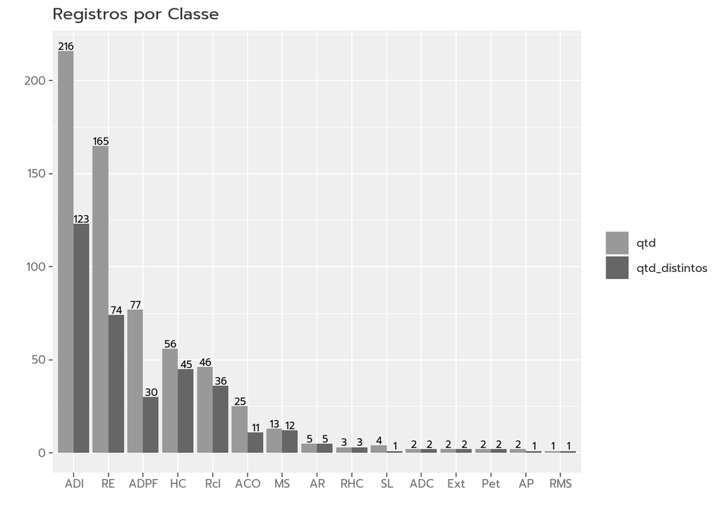

### Orgão Julgador

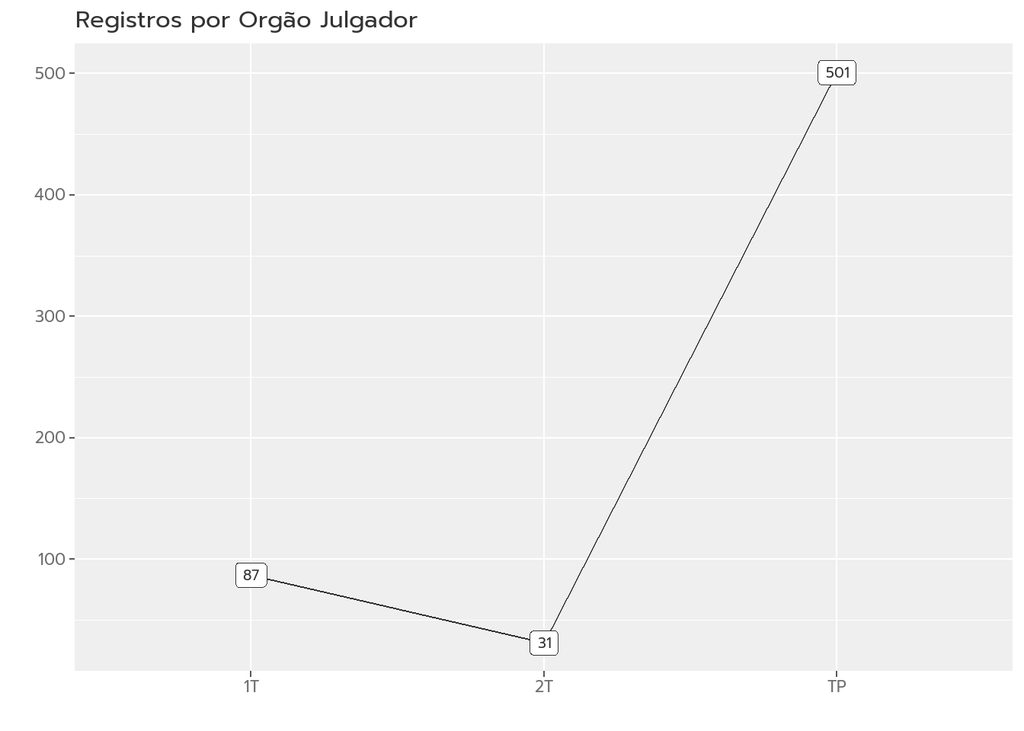

### Lista

| id | classe | ambiente | data | parte_1 | parte_2 | oab | oab_uf | periodo |
| --- | --- | --- | --- | --- | --- | --- | --- | --- |
| ACO747 | ACO | TP | 2020-05-19 | ESTADO DO RIO DE JANEIRO | MARCELO ROCHA DE MELLO MARTINS | 06541-DF | DF | pos-pandemia |
| ACO998 | ACO | TP | 2020-09-16 | ESTADO DE SÃO PAULO | WALDIR FRANCISCO HONORATO JUNIOR | 104250-SP | SP | pos-pandemia |
| ACO1257 | ACO | TP | 2020-05-12 | ESTADO DE SÃO PAULO | LEONARDO COCCHIERI LEITE CHAVES | 430513-SP | SP | pos-pandemia |
| ACO1273 | ACO | TP | 2020-05-26 | BANCO CENTRAL DO BRASIL - BACEN | ERASTO VILLA VERDE DE CARVALHO FILHO | 09393-DF | DF | pos-pandemia |
| ACO1273 | ACO | TP | 2020-05-26 | ESTADO DO PARANA | CESAR AUGUSTO BINDER | 20838-PR | PR | pos-pandemia |
| ACO1273 | ACO | TP | 2020-05-26 | ITAÚ UNIBANCO S/A | FABIO LIMA QUINTAS | 249217-SP | SP | pos-pandemia |
| ACO1904 | ACO | TP | 2020-08-25 | ITAIPÚ BINACIONAL | Francisco Rezek | NA | NA | pos-pandemia |
| ACO1904 | ACO | TP | 2020-08-25 | REPÚBLICA DO PARAGUAI | MELINA GIRARDI FACHIN | NA | NA | pos-pandemia |
| ACO1904 | ACO | TP | 2020-08-25 | UNIÃO | Isadora Maria Belem Rocha Cartaxo de Arruda | NA | NA | pos-pandemia |
| ACO1905 | ACO | TP | 2020-08-24 | TRIBUNAL DE CONTAS DA UNIÃO | RICARDO OLIVEIRA LIRA | NA | NA | pos-pandemia |

[output cut: 609 more lines]

## Pedidos de Destaque

O arquivo de pedidos de destaque possui [366](https://shiny.rstudio.com/reference/shiny/latest/fluidPage.html) entradas originalmente. Aplicando os devidos filtros para manter apenas processos do período de pesquisa, restam [176](https://shiny.rstudio.com/reference/shiny/latest/fluidPage.html) entradas em [159](https://getbootstrap.com/) processos. Especificamente para os pedidos de destaque é interessante saber quais os ministros responsáveis pelo pedido. A disposição dos pedidos por ministros será apresentada a seguir. Outras análises interessantes envolvem a classe processual e a quantidade de entradas por orgão julgador, a saber: [Primeira Turma (1T), Segunda Turma (2T) e Tribunal Pleno (TP)](https://rstudio.github.io/bslib/reference/bs_theme.html). Importante ressaltar que as entradas de pedidos de destaque ocorrem no período de 19/06/2019 a 19/03/2020 (pré-pandemia) e 20/03/2020 até 31/12/2020 (pós-pandemia). Os percentuais do quadro Orgão Julgador referem-se aos totais de decisões nos períodos em estudo e os grupos de classes são formados pelas classes ADI e ADPF (Controle Concentrado), AP, Ext, HC e RHC (Criminais), AI, ARE e RE (Recursais) e ACO, AR, MS, Pet, Rcl e RMS (Demais Originárias). Os quadros e gráficos seguem:

## Gráficos e Quadros - Pedidos de Destaque

### Ministros

Pedidos de Destaque - Ministros

| ministro_pedido_destaque | pre-pandemia | pos-pandemia |
| --- | --- | --- |
| MIN. ROBERTO BARROSO | 8 | 32 |
| MIN. ALEXANDRE DE MORAES | 17 | 18 |
| MIN. LUIZ FUX | 8 | 14 |
| MIN. CÁRMEN LÚCIA | 12 | 1 |
| MIN. GILMAR MENDES | 11 | 8 |
| MIN. RICARDO LEWANDOWSKI | 11 | 8 |
| MIN. MARCO AURÉLIO | 5 | 8 |
| MIN. DIAS TOFFOLI | 4 | 3 |
| MIN. CELSO DE MELLO | 2 | 1 |
| MIN. EDSON FACHIN | 2 | 2 |
| MIN. ROSA WEBER | 1 | 0 |

### Classes

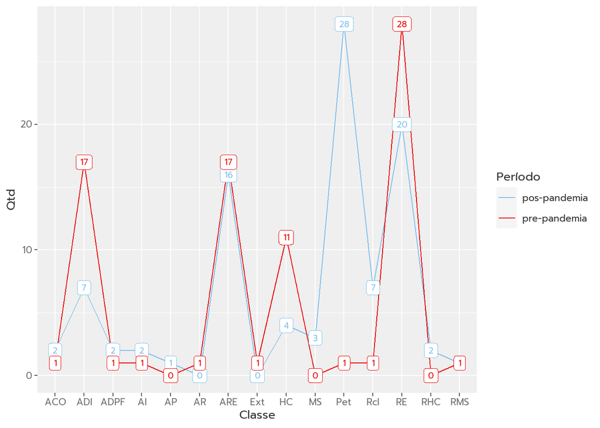

### Grupos de Classes

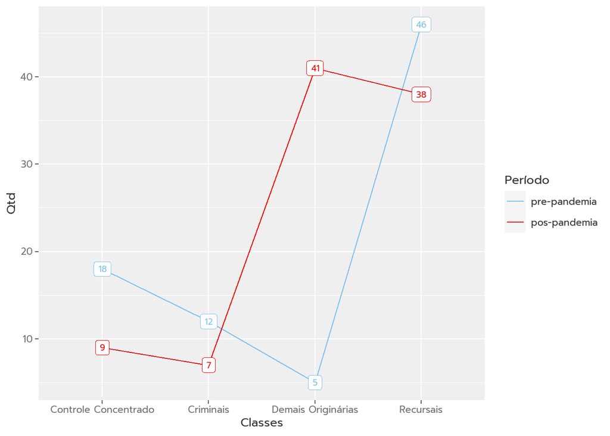

### Orgão Julgador

Pedidos de Destaque - Orgão Julgador

| ambiente | pre-pandemia | pos-pandemia |
| --- | --- | --- |
| TP | 38 / 1.40% | 45 / 0.87% |
| 1T | 24 / 0.77% | 33 / 0.57% |
| 2T | 19 / 0.47% | 17 / 0.35% |

### Lista

| id | classe | ambiente | tipo | data | ministro | periodo |
| --- | --- | --- | --- | --- | --- | --- |
| ACO1560 | ACO | TP | ACO-AgR-terceiro | 2020-02-17 | MIN. RICARDO LEWANDOWSKI | pre-pandemia |
| ACO1978 | ACO | 1T | ACO-ED | 2020-09-22 | MIN. ALEXANDRE DE MORAES | pos-pandemia |
| ACO2658 | ACO | 1T | ACO-AgR | 2020-03-20 | MIN. ROBERTO BARROSO | pos-pandemia |
| ADI2902 | ADI | TP | Mérito | 2019-12-17 | MIN. ALEXANDRE DE MORAES | pre-pandemia |
| ADI2923 | ADI | TP | Mérito | 2020-08-26 | MIN. GILMAR MENDES | pos-pandemia |
| ADI3110 | ADI | TP | Mérito | 2019-12-17 | MIN. ALEXANDRE DE MORAES | pre-pandemia |
| ADI3395 | ADI | TP | Mérito | 2019-10-10 | MIN. ALEXANDRE DE MORAES | pre-pandemia |
| ADI3424 | ADI | TP | Mérito | 2019-11-27 | MIN. GILMAR MENDES | pre-pandemia |
| ADI3529 | ADI | TP | Mérito | 2019-10-08 | MIN. ALEXANDRE DE MORAES | pre-pandemia |
| ADI3782 | ADI | TP | ADI-ED | 2020-09-14 | MIN. LUIZ FUX | pos-pandemia |

[output cut: 166 more lines]